# Assignment 4 - Clustering

Martí Paredes Salom

2023-12-13

# Introduction

In this fourth assignment about clustering we are going to use the data set `penguindata` that includes measurements taken for penguins in Palmer Archipelago. Let’s load the data and take a look at the variables.

```r
df <- read.csv("penguindata.csv")
head(df)
```

```
##   X bill_length_mm bill_depth_mm flipper_length_mm body_mass_g    sex year
## 1 1           39.1          18.7               181        3750   male 2007
## 2 2           39.5          17.4               186        3800 female 2007
## 3 3           40.3          18.0               195        3250 female 2007
## 4 4             NA            NA                NA          NA   <NA> 2007
## 5 5           36.7          19.3               193        3450 female 2007
## 6 6           39.3          20.6               190        3650   male 2007
```

```r
set.seed(1234)
```

As we can see this is a small data frame in therms of variables, we only have 7 and one is the id that we can easily discard, the meaning of the variables is the following:

- bill length mm: A number denoting bill length in millimeters
- bill depth mm: A number denoting bill depth in millimeters
- flipper length mm: An integer denoting flipper length in millimeters
- body mass g: An integer denoting body mass in grams
- sex: A factor denoting penguin sex, being female or male
- year: An integer denoting the study year (2007, 2008, or 2009)

# Data cleanup and preprocessing

The first thing we are gonna do is cleaning the data and converting all the variables into data that we can process easily and taking in account the possible Nan’s that could be present.

As we commented before the columns of X, that acts as an identifier can be removed from the df as it doesn’t give us any relevant information, the next step is to encode the column sex as a binary, where 0 represents a female penguin and 1 a male. The column year we are going to delete it as it has not sense classifing by looking at the year of observation. To finish the transformation on our df we are going to transform the variable body_mass_g into body_mass_kg, this way we are going to have smaller values maintaining the same relation.

```r
df$sex <- ifelse(df$sex == "female", 0, 1)
df$body_mass_kg <- df$body_mass_g / 1000

df <- df[, !names(df) %in% c("year", "X", "body_mass_g")]
```

Now we are going to take a look at the Nan’s of our df, as we saw on the first head of the data we can see a row with all null values unless the year of observation, we can list all the rows that’s missing atleast half of the values to see if there are more entries like this.

```r
missing_percentage <- rowMeans(is.na(df)) * 100
rows_with_high_missing <- which(missing_percentage > 50)
df[rows_with_high_missing, ]
```

```
##     bill_length_mm bill_depth_mm flipper_length_mm sex body_mass_kg
## 4               NA            NA                NA  NA           NA
## 272             NA            NA                NA  NA           NA
```

As we can see we have 2 records of penguins that only have the observation year as a valid column, as this records doesn’t give us any useful information we will be removing them from our data.

```r
missing_percentage <- rowMeans(is.na(df)) * 100
rows_to_keep <- which(missing_percentage <= 50)
df <- df[rows_to_keep, ]

columns_with_na_count <- colSums(is.na(df))
columns_with_na <- columns_with_na_count > 0

columns_with_na_info <- data.frame(
  ColumnName = names(columns_with_na_count[columns_with_na]),
  NumNA = columns_with_na_count[columns_with_na]
)

columns_with_na_info
```

```
##     ColumnName NumNA
## sex        sex     9
```

As we can see we have 9 values with Nan on the sex, in this case as this is the only value that’s missing we will fill them with the mode of the sex, as the sex being a factor it doesn’t have any sense to fill with the mean.

```r
frequency_table <- table(df$sex)
mode <- as.numeric(names(frequency_table)[frequency_table == max(frequency_table)])
df$sex[is.na(df$sex)] <- mode
```

Now that we have our df clean we will take a more in depth look of the data, we will make some plots to see how the data is correlated.

# Data exploration

To plot the data we will be using the library GGally, an extension to the ggplot2 module, this allow us to create very nice plots with a simple functions, first of all we will take a general look.

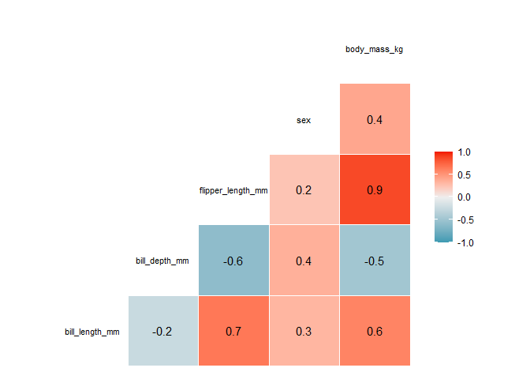

```r
library(ggplot2)
library(GGally)
ggcorr(data = df, palette = "RdYlBu", label = TRUE, size = 3)
```

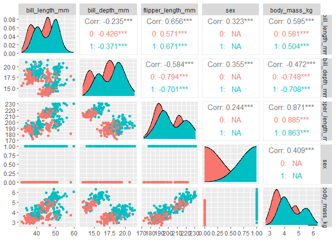

```r
ggpairs(df, aes(color = as.factor(sex)))
```

# Clustering

Clustering is a technique in unsupervised machine learning where the goal is to group similar data points into clusters or groups. The objective is to maximize the similarity within clusters and minimize the similarity between clusters, in this case we want to group the diferent groups of penguins that are hidden in our data.

First of all we need to scale our data, this is important due to the nature of clustering that’s based on distances and it’s important to leave the categorical data untouched.

```r
numeric_columns <- c("bill_length_mm", "bill_depth_mm", "flipper_length_mm", "body_mass_kg")

numeric_data <- df[, numeric_columns]
sex <- df[, c("sex")]

scaled_numeric_data <- scale(numeric_data)

df_scaled <- cbind(scaled_numeric_data, sex)
```

```r
pca_result <- prcomp(numeric_data)
summary(pca_result)
```

```
## Importance of components:
##                            PC1     PC2    PC3     PC4
## Standard deviation     14.6097 4.01455 1.5389 0.39109
## Proportion of Variance  0.9197 0.06944 0.0102 0.00066
## Cumulative Proportion   0.9197 0.98914 0.9993 1.00000
```

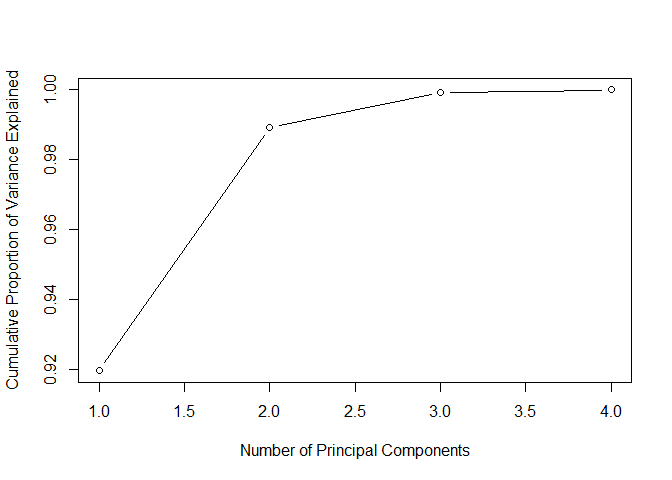

```r
plot(cumsum(pca_result$sdev^2 / sum(pca_result$sdev^2)), type = "b",
     xlab = "Number of Principal Components", ylab = "Cumulative Proportion of Variance Explained")
```

As we can see with two PC we could have a 98% of the data explained, but knowing that we have a rather small dataframe we will be taking three principal components, reducing in one the number of components of the original data frame.

The PCA can only be applied to numerical data so we have to append the column sex to this reduced data frame.

```r
df_f <- cbind(as.data.frame(pca_result$x[,1:3]), sex)
head(df_f)
```

```
##          PC1        PC2        PC3 sex
## 1 -20.536754 -0.6370583 -0.1232666   1
## 2 -15.527865  0.4240502 -0.9022052   0
## 3  -6.749553  1.8493093  0.5721102   0
## 5  -9.715005  4.6131540  2.0469694   0
## 6 -11.996902  1.1867319  2.7139498   1
## 7 -20.525866 -0.3225340 -0.9925549   0
```

## K-Means

The first unsupervised clustering tecnique that we are going to try is KMeans, this algorithm partitions a dataset into K clusters, where each data point belongs to the cluster with the nearest mean. The values of the function are: - centers: Number of cluster that we are going to assign. - nstart: Number of times the K-Means algorithm will be run with different initial cluster centers.

We will create a first model with 3 clusters and we are going to plot the results

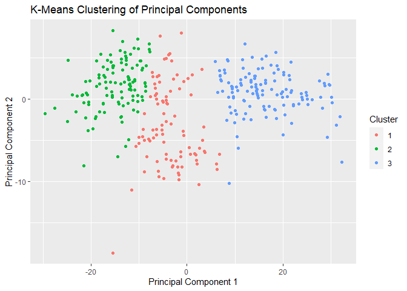

```r
kmeans_result <- kmeans(df_f, centers = 3, nstart = 20)
df_f$cluster <- as.factor(kmeans_result$cluster)

ggplot(df_f, aes(PC1, PC2, color = cluster)) +
  geom_point() +
  labs(title = "K-Means Clustering of Principal Components", x = "Principal Component 1", y = "Principal Component 2", color = "Cluster", shape = "Sex")
```

As we can see the results are dificult to interpret, how good is this clustering, what’s the optimal number of clustering needed, what are features of each cluster? Let’s go one by one and try to answer each of this questions. To determine the optimal number of clusters, we’ll utilize the Within-Cluster Sum of Squares (WSS) method. WSS gauges the sum of squared distances between each data point and its cluster’s centroid, indicating cluster compactness. By plotting these values, we’ll observe an “elbow” point, where the reduction in WSS slows down, transitioning from a steep curve to a gentler slope. This elbow point signifies an optimal cluster count, striking a balance between compact clusters and avoiding excessive fragmentation or oversimplification.

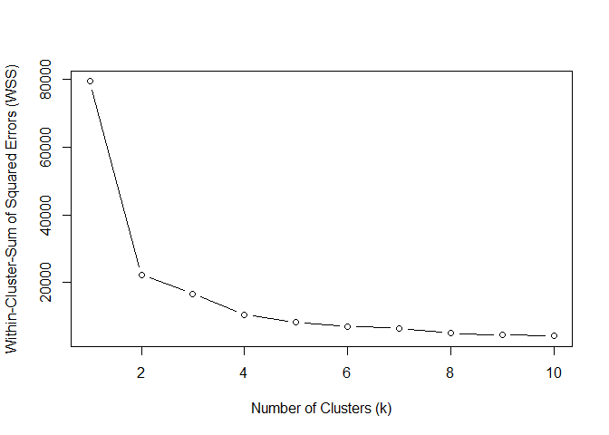

```r
wss_values <- numeric()

for (k in 1:10) {
  kmeans_result <- kmeans(df_f, centers = k)
  wss_values[k] <- sum(kmeans_result$withinss)
}


plot(1:10, wss_values, type = "b", xlab = "Number of Clusters (k)", ylab = "Within-Cluster-Sum of Squared Errors (WSS)")
```

```r
library(plotly)
kmeans_result_3 <- kmeans(df_f, centers = 3, nstart = 20)
df$cluster_3 <- as.factor(kmeans_result_3$cluster)

p <- plot_ly(df_f, x=~PC1, y=~PC2,
z=~PC3, color=~df$cluster_3, size=1.5)
p
```

[interactive chart not shown]

As we can observe we have two big clouds of points with a space between them so it makes sense that if we have three groups individuals are not mixed in the two clouds. Let’s take a look at the means of the different groups.

```r
cluster_means_k3 <- aggregate(. ~ cluster_3, data = df, mean)
cluster_means_k3
```

```
##   cluster_3 bill_length_mm bill_depth_mm flipper_length_mm       sex
## 1         1       45.95484      18.70108          196.7312 0.6559140
## 2         2       38.42750      18.02167          186.9917 0.3666667
## 3         3       47.56744      15.22403          216.8837 0.5581395
##   body_mass_kg
## 1     3.898387
## 2     3.543958
## 3     5.032364
```

Observing the dataset, it’s apparent that the gender distribution across groups is fairly balanced. However, disparities emerge when considering other variables, indicating varying ranges in sizes. Notably, there is a discernible pattern where larger flippers and bills correlate with increased body mass. This suggests potential classifications: Cluster 3 might represent adult penguins, Cluster 1 could denote younger individuals, and Cluster 2 possibly includes smaller specimens. Alternatively, these distinctions may indicate different species within the penguin population.

Now let’s repeat this process with four clusters and observe how the data reacts to this new cluster.

```r
kmeans_result_4 <- kmeans(df_f, centers = 4, nstart = 20)

df$cluster_4 <- as.factor(kmeans_result_4$cluster)

p <- plot_ly(df_f, x=~PC1, y=~PC2,
z=~PC3, color=~df$cluster_4, size=1.5)
p
```

[interactive chart not shown]

```r
cluster_means_k4 <- aggregate(. ~ cluster_4, data = df, mean)
cluster_means_k4
```

```
##   cluster_4 bill_length_mm bill_depth_mm flipper_length_mm       sex
## 1         1       45.72333      18.67222          196.3111 0.6444444
## 2         2       46.37561      15.14146          212.1707 0.3658537
## 3         3       38.40924      18.01513          186.9412 0.3613445
## 4         4       49.66078      15.68235          223.5490 0.9019608
##   body_mass_kg cluster_3
## 1     3.878333  1.011111
## 2     4.731098  2.902439
## 3     3.541807  2.000000
## 4     5.461275  3.000000
```

## Hierarcical clustering

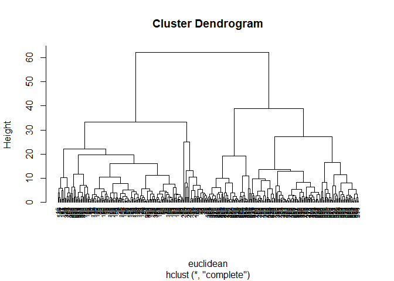

```r
euclidean <- dist(df_f)
hc <- hclust(euclidean, method = "complete")
plot(hc,cex = 0.6,hang = -1)
```

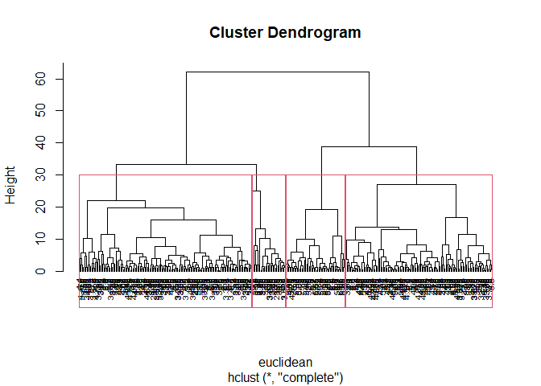

```r
clusters <- 4

plot(hc, cex = 0.6,hang = -1, labels=df$body_mass_kg)
rect.hclust(hc, k=clusters)
```

```r
groups <- cutree(hc, k=clusters)
```